# Unsupervised Learning for anomaly detection in options pricing

the Black-Scholes model,

- the model assumes that the underlying volatility ($\sigma$) is constant
- no fractional fees
- stock returns follow lognormal distribution
- no dividend payout
- European options.

```python
import math
import matplotlib
import numpy as np
import pandas as pd
import seaborn as sns
import time
from sklearn.ensemble import IsolationForest
from matplotlib import pyplot as plt
from pylab import rcParams
from sklearn.metrics import mean_squared_error
from tqdm import tqdm_notebook
from xgboost import XGBRegressor

%matplotlib inline
```

From FRM AND CFA **Implied volatility** $\sigma$: violitility **Delta**: $\delta$changes of violitility **Gamma**: The $\gamma$ change of delta **Vega**: sensitive the option price is to a change in the implied volatility

#### 2. What options pricing data do we have?

The data is from historicaloptiondata.com.

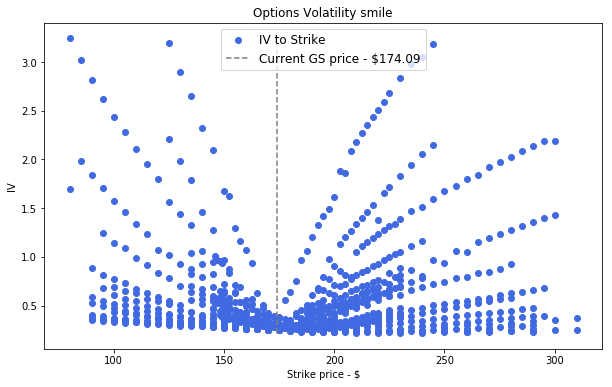

```python
import pandas as pd
# Filtered options data for Goldman Sachs
options_df = pd.read_csv('option_GS_df.csv', parse_dates=["Expiration", ' DataDate'])
options_df.drop(options_df.columns[0],axis=1,inplace=True)
options_df['date_diff'] = (options_df['Expiration'] - options_df[' DataDate']).dt.days
options_df['Spread'] = options_df['Ask'] - options_df['Bid']


curr_price_ = options_df.iloc[0,0]
plt.figure(figsize=(10, 6))
plt.scatter(options_df.Strike, options_df.IVAsk, label='IV to Strike', \
            c='royalblue')
plt.vlines(curr_price_, options_df.IVAsk.min(), \
           options_df.IVAsk.max(), \
           label='Current GS price - ${}'.format(curr_price_), \
           linestyles='--', colors='gray')
plt.xlabel('Strike price - $')
plt.ylabel('IV')
plt.title('Options Volatility smile')
plt.legend(fontsize='large')
plt.savefig('./volatilitysmile.jpg', dpi=100)
plt.show()
```

```python
options_df.head()
```

|  | UnderlyingPrice | OptionSymbol | Type | Expiration | DataDate | Strike | Last | Bid | Ask | Volume | ... | IVMean | IVBid | IVAsk | Delta | Gamma | Theta | Vega | AKA | date_diff | Spread |
| --- | --- | --- | --- | --- | --- | --- | --- | --- | --- | --- | --- | --- | --- | --- | --- | --- | --- | --- | --- | --- | --- |
| 0 | 174.09 | GS160108C00125000 | call | 2016-01-08 | 2016-01-05 | 125.0 | 0.0 | 46.95 | 50.80 | 0 | ... | 0.0874 | 0.0 | 3.1911 | 1.0000 | 0.0000 | 0.0000 | 0.0000 | GS160108C00125000 | 3 | 3.85 |
| 1 | 174.09 | GS160108P00125000 | put | 2016-01-08 | 2016-01-05 | 125.0 | 0.0 | 0.00 | 0.31 | 0 | ... | 1.9822 | 0.0 | 2.2141 | -0.0150 | 0.0014 | -0.2242 | 0.0053 | GS160108P00125000 | 3 | 0.31 |
| 2 | 174.09 | GS160108C00130000 | call | 2016-01-08 | 2016-01-05 | 130.0 | 0.0 | 41.80 | 45.80 | 0 | ... | 0.0874 | 0.0 | 2.8946 | 1.0000 | 0.0000 | 0.0000 | 0.0000 | GS160108C00130000 | 3 | 4.00 |
| 3 | 174.09 | GS160108P00130000 | put | 2016-01-08 | 2016-01-05 | 130.0 | 0.0 | 0.00 | 0.31 | 0 | ... | 1.7931 | 0.0 | 1.9882 | -0.0175 | 0.0017 | -0.2310 | 0.0060 | GS160108P00130000 | 3 | 0.31 |
| 4 | 174.09 | GS160108C00135000 | call | 2016-01-08 | 2016-01-05 | 135.0 | 0.0 | 36.95 | 40.90 | 0 | ... | 0.0874 | 0.0 | 2.6480 | 1.0000 | 0.0000 | 0.0000 | 0.0000 | GS160108C00135000 | 3 | 3.95 |

5 rows × 22 columns

```python
options_df.shape
```

```
(858, 22)
```

```python
print(', '.join(x for x in options_df.columns))
```

```
UnderlyingPrice, OptionSymbol, Type, Expiration,  DataDate, Strike, Last, Bid, Ask, Volume, OpenInterest, T1OpenInterest, IVMean, IVBid, IVAsk, Delta, Gamma, Theta, Vega, AKA, date_diff, Spread
```

```python
col_names_pairplot = {
    's_k' : 'Current minus Strike',
    'b_a_mean': 'Average of Bid and Ask',
    'date_diff': 'Date difference',
    'Spread' : 'Spread', 'Delta': 'Delta', 'Gamma': 'Gamma', 'Spread':'Spread',
    'Strike': 'Strike', 'Bid':'Bid', 'Ask':'Ask', 'Vega':'Vega'
}
options_df.iloc[0,]
```

```
UnderlyingPrice                 174.09
OptionSymbol         GS160108C00125000
Type                              call
Expiration         2016-01-08 00:00:00
 DataDate          2016-01-05 00:00:00
Strike                             125
Last                                 0
Bid                              46.95
Ask                               50.8
Volume                               0
OpenInterest                         0
T1OpenInterest                       0
IVMean                          0.0874
IVBid                                0
IVAsk                           3.1911
Delta                                1
Gamma                                0
Theta                                0
Vega                                 0
AKA                  GS160108C00125000
date_diff                            3
Spread                            3.85
Name: 0, dtype: object
```

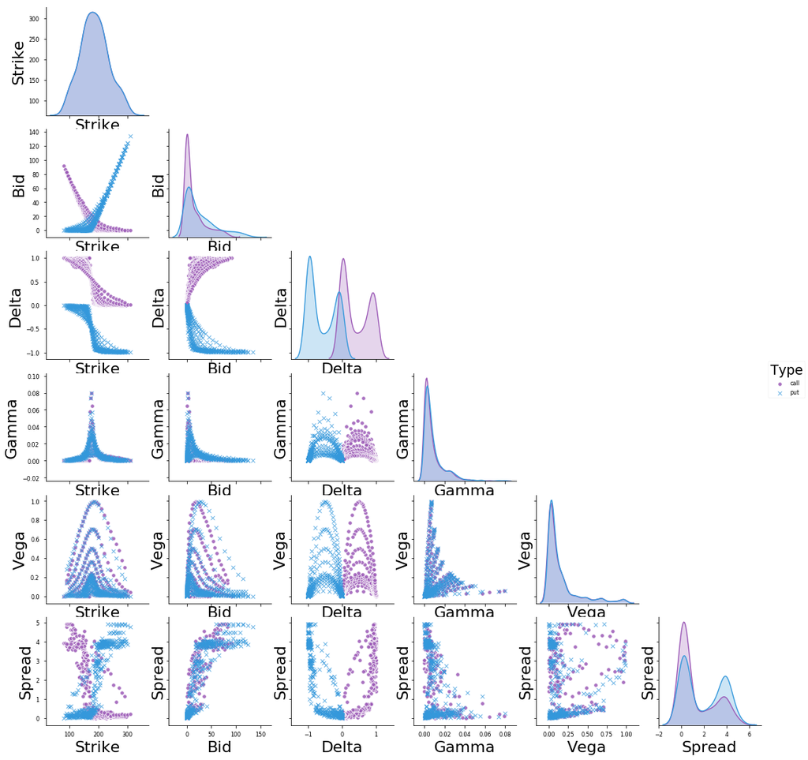

```python
sns_options_colors = ["#9b59b6", "#3498db"]
sns_options_vars = ['Strike', 'Bid', 'Delta', \
                    'Gamma', 'Vega', 'Spread']

sns.set_palette(sns.color_palette(sns_options_colors))
sns.set_context("paper", rc={"axes.labelsize": 22})

options_g = sns.pairplot(options_df, \
                         vars=sns_options_vars, \
                         diag_kind='kde', \
                         hue='Type', \
                         markers=["o", "x"], \
                         plot_kws=dict(edgecolor='white', \
                                       linewidth=.85, alpha=.85), \
                         diag_kws=dict(shade=True)
                         )

for i, j in zip(*np.triu_indices_from(options_g.axes, 1)):
    options_g.axes[i, j].set_visible(False)

xlabels, ylabels = [], []

for ax in options_g.axes[-1,:]:
    xlabel = ax.xaxis.get_label_text()
    xlabels.append(xlabel)
for ax in options_g.axes[:,0]:
    ylabel = ax.yaxis.get_label_text()
    ylabels.append(ylabel)

i,j=0,0
for i in range(len(xlabels)):
    for j in range(len(ylabels)):
        options_g.axes[j,i].xaxis.set_label_text(col_names_pairplot[xlabels[i]])
        options_g.axes[j,i].yaxis.set_label_text(col_names_pairplot[ylabels[j]])

plt.savefig('./options_pairplot.jpg')
plt.show()
```

**Note**: The purple-ish color represents the calls, and the blue - the puts.

#### 3. Unsupervised learning for finding outliers (anomaly)

**What would be an anomaly?** Anomaly in our case would be any mismatch in the logic of the options. **For example**, the Bid (or Ask) prices of two call options that have the same Strike price but, say, 1-2 days difference in the Exercise day should be almost identical (unless there is something unusual, which should somehow be accounted for in the greeks). So, a big difference in the Bid prices of these two options would not be 'normal'. Or, for instance, high Theta or small Vega on an (*OTM*) option with long time to expiration. And so on.

For the purpose of anomaly detection we will use **Isolation Forest**.

```python
it_X_train = options_df[['Strike', 'Delta', 'Gamma', 'date_diff']]
it_X_train['s_k'] = options_df['UnderlyingPrice'] - options_df['Strike']
it_X_train['b_a_mean'] = (options_df['Bid'] + options_df['Ask']) / 2
it_X_train['b_a_mean'] = it_X_train['b_a_mean'].apply(lambda x: int(round(x, 0)))
it_X_train['s_k'] = it_X_train['s_k'].apply(lambda x: int(round(x, 0)))
```

```python
col_names = {
    's_k' : 'Difference between Current and Strike prices',
    'b_a_mean': 'Average of Bid and Ask',
    'date_diff': 'Difference between Date of valuation and Exercise date',
    'Spread' : 'Spread', 'Delta': 'Delta', 'Gamma': 'Gamma',
    'Strike': 'Strike', 'Bid':'Bid', 'Ask':'Ask', 'Vega':'Vega', 'Type':'Type',
    'y' : 'Anomaly', 'Type': 'Option type (call or put)', 'Last': 'Last trading price'
}
```

```python
print('The features we will use are {}.'.
      format(', '.join(col_names[x] for x in it_X_train.columns)))
```

```
The features we will use are Strike, Delta, Gamma, Difference between Date of valuation and Exercise date, Difference between Current and Strike prices, Average of Bid and Ask.
```

```python
clf = IsolationForest(max_samples='auto', contamination=.025,\
                      n_estimators=10, \
                      random_state=19117, max_features=it_X_train.shape[1])
clf.fit(it_X_train)

y_pred_train = clf.predict(it_X_train)
```

```python
it_X_train['y'] = y_pred_train
```

```python
it_X_train['Type'] = options_df['Type']
```

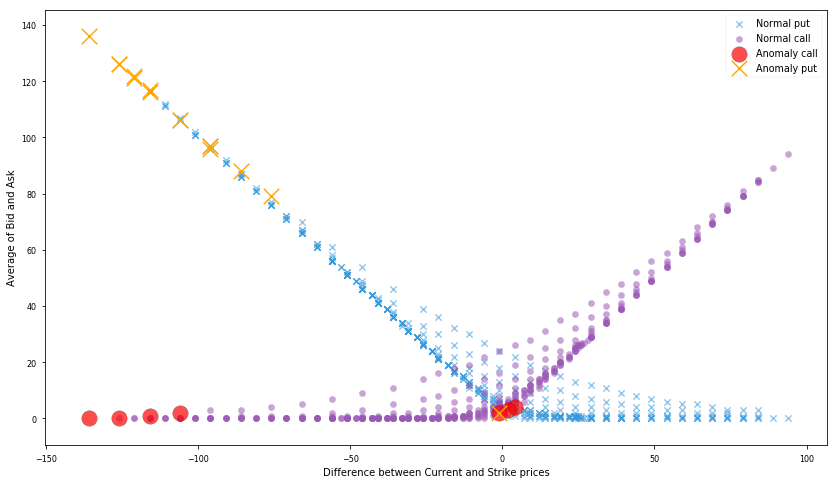

```python
it_outlier = -1

sns_options_colors = ["#9b59b6", "#3498db"]
sns.set_palette(sns.color_palette(sns_options_colors))
sns.set_context("paper", rc={"axes.labelsize": 10})
plt.figure(figsize=(14, 8))

it_x_ = 's_k'
it_y_ = 'b_a_mean'


plt.scatter(it_X_train[(it_X_train['y']==1) & (it_X_train['Type']=='put')][it_x_], \
            it_X_train[(it_X_train['y']==1) & (it_X_train['Type']=='put')][it_y_], \
            label='Normal put', c=sns_options_colors[1], s=10*4, alpha=.55, marker='x')

plt.scatter(it_X_train[(it_X_train['y']==1) & (it_X_train['Type']=='call')][it_x_], \
            it_X_train[(it_X_train['y']==1) & (it_X_train['Type']=='call')][it_y_], \
            label='Normal call', c=sns_options_colors[0], s=10*4, alpha=.55, marker='o')

plt.scatter(it_X_train[(it_X_train['y']==-1) & (it_X_train['Type']=='call')][it_x_], \
            it_X_train[(it_X_train['y']==-1) & (it_X_train['Type']=='call')][it_y_], \
            label='Anomaly call', c='red', s=60*4, edgecolor='black', marker='o', alpha=.7)

plt.scatter(it_X_train[(it_X_train['y']==-1) & (it_X_train['Type']=='put')][it_x_], \
            it_X_train[(it_X_train['y']==-1) & (it_X_train['Type']=='put')][it_y_], \
            label='Anomaly put', c='orange', s=60*4, edgecolor='black', marker='x')

plt.xlabel(col_names[it_x_])
plt.ylabel(col_names[it_y_])
plt.legend(fontsize='medium')

plt.show()
```

```python
col_names_pairplot = {
    's_k' : 'Current minus Strike',
    'b_a_mean': 'Average of Bid and Ask',
    'date_diff': 'Date difference',
    'Spread' : 'Spread', 'Delta': 'Delta', 'Gamma': 'Gamma', 'Spread':'Spread',
    'Strike': 'Strike', 'Bid':'Bid', 'Ask':'Ask', 'Vega':'Vega'
}
```

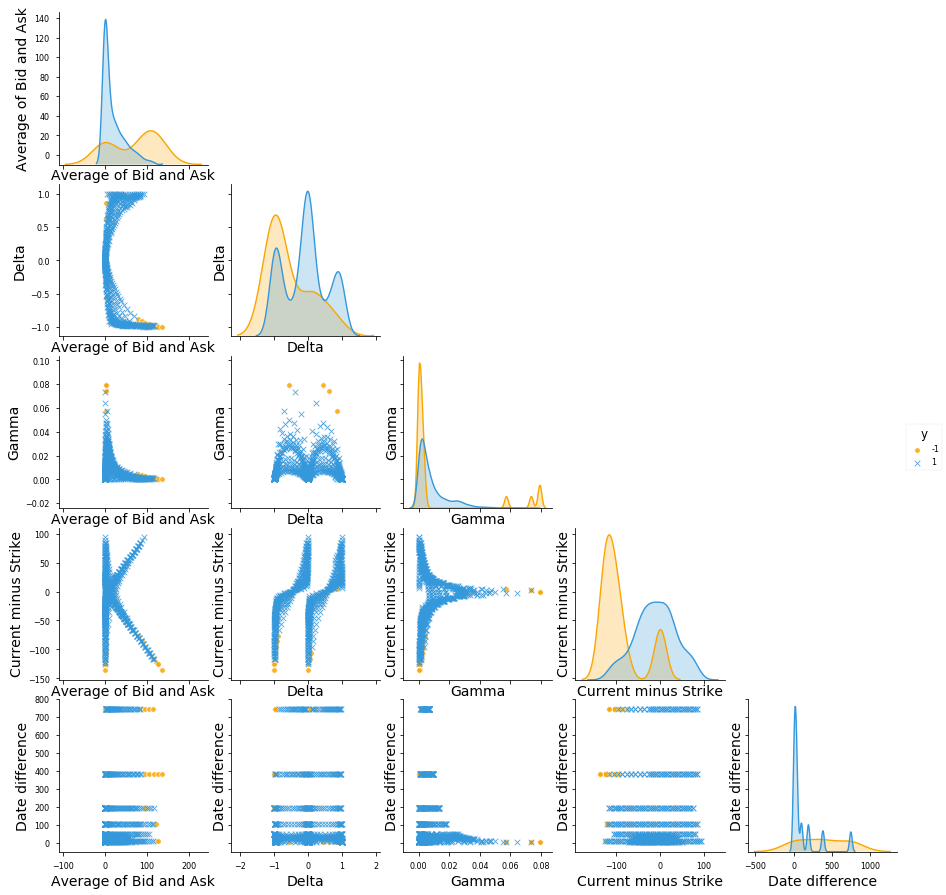

```python
sns_options_colors = ["#f9a602", "#3498db"]

sns_options_vars = ['b_a_mean', 'Delta', 'Gamma', 's_k', 'date_diff']
sns.set_palette(sns.color_palette(sns_options_colors))
sns.set_context("paper", rc={"axes.labelsize": 14})

options_g = sns.pairplot(it_X_train, \
                         vars=sns_options_vars, \
                         diag_kind='kde', \
                         hue='y', \
                         markers=["o", "x"], \
                         plot_kws=dict(edgecolor='white', \
                                       linewidth=.85, alpha=.85), \
                         diag_kws=dict(shade=True),\
                         )

for i, j in zip(*np.triu_indices_from(options_g.axes, 1)):
    options_g.axes[i, j].set_visible(False)

xlabels, ylabels = [], []

for ax in options_g.axes[-1,:]:
    xlabel = ax.xaxis.get_label_text()
    xlabels.append(xlabel)
for ax in options_g.axes[:,0]:
    ylabel = ax.yaxis.get_label_text()
    ylabels.append(ylabel)

for i in range(len(xlabels)):
    for j in range(len(ylabels)):
        options_g.axes[j,i].xaxis.set_label_text(col_names_pairplot[xlabels[i]])
        options_g.axes[j,i].yaxis.set_label_text(col_names_pairplot[ylabels[j]])

plt.show()
```

The blue -normal

```python
print('So for every day of the training data we have', options_df.shape[0]*options_df.shape[1], 'data points.')
```

```
So for every day of the training data we have 18876 data points.
```

Using autoencoders also makes good sense for anomaly detection.

```python
!jupyter nbconvert anomaly-plots-options.ipynb --to html
```

```
[NbConvertApp] Converting notebook anomaly-plots-options.ipynb to html
[NbConvertApp] Writing 923439 bytes to anomaly-plots-options.html
```